# 3 Logistic Regression 1

Author

Lin Yu

Published

February 3, 2025

```r
library(dplyr)
library(ggplot2)
library(DT)
library(here)
```

## 3.1 Recap of Tutorial 2

Let’s review several fundamental statistical concepts:

1. In the following simple linear model, which component(s) are random, and which are fixed/constant?

$Y = X\beta + \epsilon \quad \text{or} \quad E(Y\mid X) = X\beta, \quad \text{where} \quad \epsilon \sim N(0, \sigma^2)$

**Check Answer**

-$Y$ is random and assumed to follow a normal distribution with mean $X\beta$ and variance$\sigma^2$ for each individual (recall the LINE assumptions).  
- The parameter$\beta$ is a constant (in the frequentist view) but unknown.  
-$X$ is fixed.  
-$\epsilon$ is random.

2. What are the estimand, estimator, and estimate?

**Check Answer**

Using simple linear regression as an example:

- The **estimand** is the parameter we aim to estimate, which is$\beta$.
- An **estimator** is a function of the data used to estimate$\beta$. The maximum likelihood estimator (MLE) for$\beta_1$ is: $\hat{\beta}_1 = \frac{\sum_{i=1}^{n} (X_i - \bar{X})(Y_i - \bar{Y})}{\sum_{i=1}^{n} (X_i - \bar{X})^2}$

Different estimators can be proposed; for example, if one proposed $\tilde{\beta}_1 = \bar{Y}$, it would likely fail to capture the true association between $X$ and $Y$.

- An **estimate** is the specific numerical value obtained from an estimator after applying it to observed data. Since data are random, the estimator $\hat{\beta}$ is also random. However, for a specific dataset, the estimate is a fixed number.
3. What are standard error and standard deviation? Which varies with sample size and why?

**Check Answer**

- The **standard error (SE)** is the standard deviation of an estimator. It quantifies the variability of the estimator across different samples. Since the precision of an estimator depends on the sample size, a larger sample size leads to a smaller standard error.
- The **standard deviation (SD)** measures the variability of the data itself. For example, the variation in heights within a classroom is a fixed property of the data and does not depend on the sample size.
4. What is a linear regression model, and which of the following models are linear?

1.$E(Y\mid X) = \beta_1X + \beta_2 X^2$  
2.$E(Y\mid X) = \beta_1X + \beta_2 \log(X)$  
3.$\log(E(Y\mid X)) = \beta_1X + \beta_2 X^2$  
4.$E(Y\mid X)= \beta_1X + \beta_2^2X$

**Check Answer**

All models except the last one are linear models.

- **Linearity in regression refers to linearity in parameters, not necessarily in predictors.**
- The first three models are linear in regression parameters$\beta_1$ and$\beta_2$, even though they include transformations of $X$.
- The fourth model is **not** linear because $\beta_2^2$ introduces a non-linear transformation of a parameter.

## 3.2 Tutorial 3

Today, we’ll work on logistic regression.

```r
library(rms)
library(here)
load(here("data","tutdata.RData"))
dd <- datadist(tutdata)
options(datadist = "dd")

fit <- lrm(y ~ blood.pressure + sex + age + rcs(cholesterol, 4), data = tutdata)

anova(fit)
```

```
                Wald Statistics          Response: y

 Factor         Chi-Square d.f. P
 blood.pressure  0.33      1    0.5640
 sex            13.45      1    0.0002
 age            25.58      1    <.0001
 cholesterol     1.27      3    0.7368
  Nonlinear      0.78      2    0.6758
 TOTAL          38.63      6    <.0001
```

```r
fit %>% coef()
```

```
     Intercept blood.pressure       sex=male            age    cholesterol
  -0.770428669   -0.002482989    0.477026128    0.033321608   -0.004418957
  cholesterol'  cholesterol''
   0.022754677   -0.098270674
```

```r
fit %>% vcov()
```

```
                   Intercept blood.pressure      sex=male           age
Intercept       3.0234267326  -2.096123e-03 -1.919335e-04 -1.799902e-03
blood.pressure -0.0020961233   1.852472e-05 -4.542393e-06 -1.048266e-06
sex=male       -0.0001919335  -4.542393e-06  1.691277e-02  3.642625e-05
age            -0.0017999015  -1.048266e-06  3.642625e-05  4.340282e-05
cholesterol    -0.0155094677  -5.297436e-07 -5.161492e-05 -1.592218e-06
cholesterol'    0.0379635708   4.065325e-06  1.122060e-04  5.500943e-06
cholesterol''  -0.1361901376  -1.938549e-05 -3.636389e-04 -2.046384e-05
                 cholesterol  cholesterol' cholesterol''
Intercept      -1.550947e-02  3.796357e-02 -1.361901e-01
blood.pressure -5.297436e-07  4.065325e-06 -1.938549e-05
sex=male       -5.161492e-05  1.122060e-04 -3.636389e-04
age            -1.592218e-06  5.500943e-06 -2.046384e-05
cholesterol     9.119299e-05 -2.315889e-04  8.424284e-04
cholesterol'   -2.315889e-04  7.331333e-04 -2.936085e-03
cholesterol''   8.424284e-04 -2.936085e-03  1.241586e-02
```

```r
## point estimate of beta_sex
beta_sex_hat <- coef(fit)["sex=male"]

## standard error for coef of sex
beta_sex_se <- sqrt(vcov(fit)[3,3])

## we know beta_hat follows a normal distribution, with mean=beta_sex_hat,

alpha <- qnorm(0.975,mean=0,sd=1)
alpha
```

```
[1] 1.959964
```

```r
upper <- exp(beta_sex_hat + alpha*beta_sex_se)
lower <- exp(beta_sex_hat - alpha*beta_sex_se)

lower
```

```
sex=male
1.248739
```

```r
upper
```

```
sex=male
2.079064
```

The odds of the outcome for males is 1.61 times that for females (95% CI of 1.25 to 2.08) controlled for blood pressure, age and cholesterol.

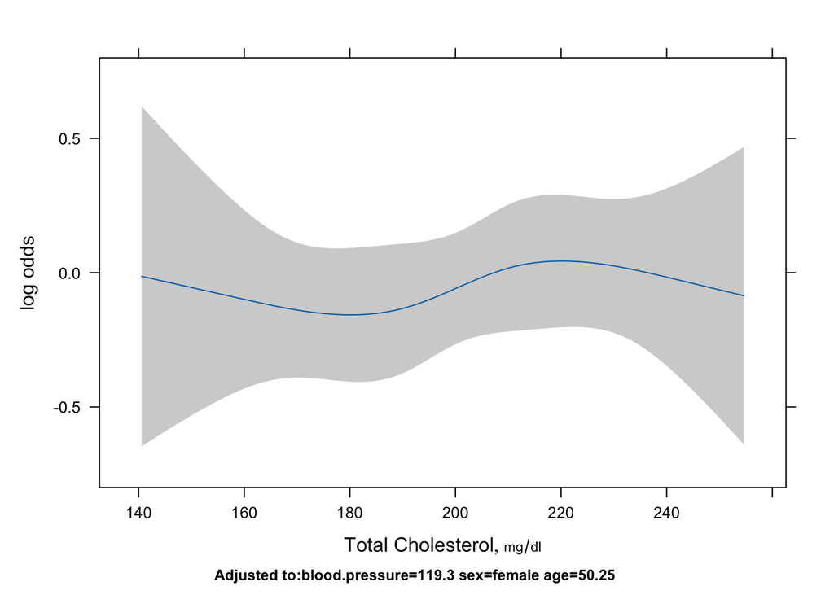

```r
## log odds
plot(Predict(fit, cholesterol))
```

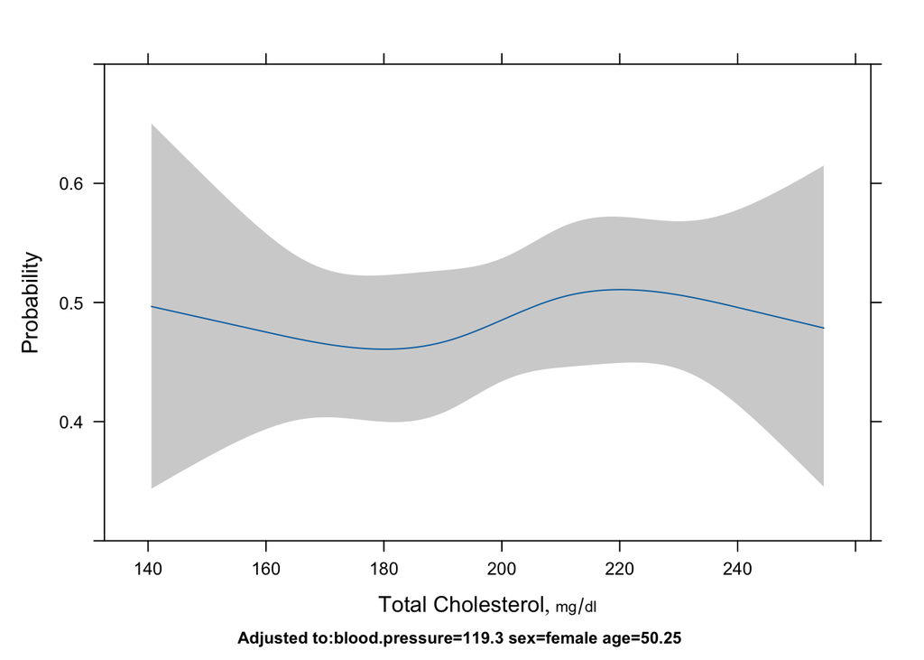

```r
## probability
plot(Predict(fit, cholesterol, fun = plogis), ylab = "Probability")
```

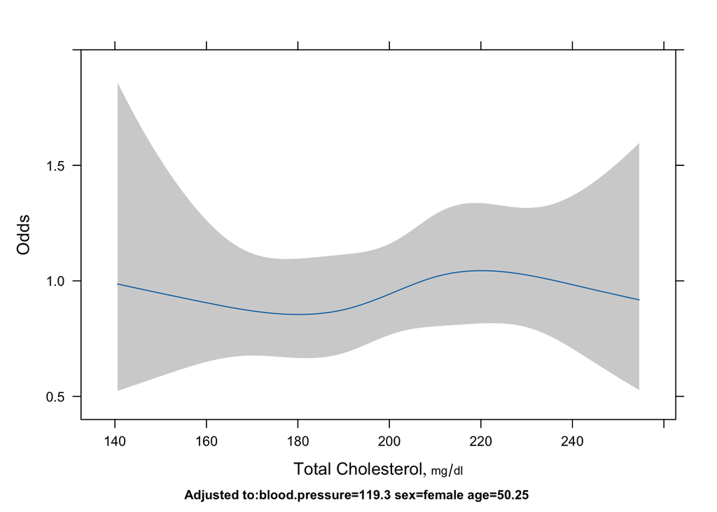

```r
## Odds

plot(Predict(fit, cholesterol, fun = exp), ylab = "Odds")
```